# Exploring the 2015 PHP framework survey by Sitepoint

Jesus M. Castagnetto

April 01, 2015

## Background

Sitepoint has published the results of their 2015 PHP Framework popularity survey[^1]. In that post they show that the survey gives a very large edge to Laravel. The people at Sitepoint were also nice enought to publish their properly anonymized dataset in a github repo[^2]

So I went ahead, and forked their repo and fired up R to give this data a go.

## Exploring the dataset

I read the survey into a data frame, and looked at the overall structure:

```r
library("dplyr")
library("reshape2")
library("ggplot2")
library("knitr")
library("ROCR")
library("rpart")
library("rpart.plot")
survey <- tbl_df(read.csv("../dump/survey.csv", stringsAsFactors = FALSE))
glimpse(survey)
```

```
## Variables:
## $ id                           (int) 76, 70, 71, 72, 68, 69, 66, 87, 9...
## $ start.date                   (chr) "2015-02-27 17:16:59", "2015-02-2...
## $ submit.date                  (chr) "2015-02-27 17:19:23", "2015-02-2...
## $ network                      (chr) "7387618cfa96eeb8ac02785f782af164...
## $ age.group                    (int) 4, 3, 4, 4, 3, 3, 3, 2, 3, 3, 2, ...
## $ country                      (chr) "Slovenia", "France", "United Sta...
## $ years.php                    (int) 10, 7, 15, 10, 8, 10, 6, 3, 14, 5...
## $ years.programming            (int) 19, 13, 15, 20, 11, 15, 15, 5, 16...
## $ education                    (int) 1, 5, 6, 1, 5, 2, 3, 5, 5, 5, 5, ...
## $ numframeworks                (int) 2, 3, 2, 4, 4, 3, 1, 3, 2, 1, 2, ...
## $ fw.work.choice               (chr) "CodeIgniter", "Symfony2", "Compa...
## $ fw.work.other                (chr) "", "", "", "", "", "", "", "", "...
## $ fw.work.reason.easy          (chr) "1", "", "", "1", "1", "1", "1", ...
## $ fw.work.reason.community     (int) 1, NA, NA, NA, NA, 1, NA, NA, 1, ...
```

[output cut: 39 more lines]

It seems that the first 30 columns related to personal information and preferences for each respondent (identified by the `id` field). The next 22 columns comprise a very sparse matrix that encodes what frameworks (including a write-in option) the respondent has made contributions.

So I decided to look extract that section of the dataset and do some quick analysis looking at the frequencies, and how it compared with the results of framework popularity.

The reason to do that, is to try and get a feeling on the extent to which each project (framework) has a community that not only benefits from it, but also works towards improving it by contributing to the code, documentation, etc.

Let’s look first at the contributions to the list of selected frameworks:

```r
# the framework contribution "matrix"
contrib <- survey %>% select(id,laravel:agavi)
ncontrib <- as.data.frame(
  table(rowSums(contrib[, -1], na.rm=TRUE))) %>%
  mutate(pFreq=round(100*Freq/nrow(contrib), 2))
colnames(ncontrib) <- c("Number of frameworks",
                       "Count", "Percent of total")
kable(ncontrib, align=c("c", "c", "c"),
      caption="Distribution of number of frameworks contributed to by respondents")
```

Distribution of number of frameworks contributed to by respondents

| Number of frameworks | Count | Percent of total |
| --- | --- | --- |
| 0 | 6327 | 81.80 |
| 1 | 1033 | 13.35 |
| 2 | 239 | 3.09 |
| 3 | 84 | 1.09 |
| 4 | 31 | 0.40 |
| 5 | 11 | 0.14 |
| 6 | 4 | 0.05 |
| 7 | 5 | 0.06 |
| 8 | 1 | 0.01 |

So, about 18.2% of survey respondents contribute to at least one framework (without including the “write-ins”)

Now, I will convert the data from a “wide” to a “long” format, using the `reshape2` package, and also mangle the the write-ins (`other` field) to be able to combine that with the other data.

```r
contrib.long <- melt(contrib, id.vars = "id",
                     variable.name = "framework",
                     value.name = "count",
                     na.rm = TRUE)
head(contrib.long)
```

```
##     id framework count
## 14 134   laravel     1
## 40 214   laravel     1
## 68 328   laravel     1
## 77 365   laravel     1
## 82 381   laravel     1
## 94 427   laravel     1
```

```r
summary(contrib.long)
```

```
##        id           framework       count
##  Min.   :   99   laravel :355   Min.   :1
##  1st Qu.: 7594   symfony2:344   1st Qu.:1
##  Median :15986   yii2    :181   Median :1
##  Mean   :19142   zf2     :171   Mean   :1
##  3rd Qu.:29910   ci      :165   3rd Qu.:1
##  Max.   :47233   nette   :132   Max.   :1
##                  (Other) :661
```

It seems that the `count` field is not informative at all, so we can safely remove it.

```r
contrib.long <- contrib.long[,1:2]
```

While mangling the “write-ins”, I noticed a large amount of empty answers, which is reasonable if you consider that the options given in the survey contained the most popular frameworks.

```r
# the write-ins
contrib.writeins <- survey[,c(1,53)]
nrow(contrib.writeins)
```

```
## [1] 7735
```

```r
head(contrib.writeins)
```

```
## Source: local data frame [6 x 2]
##
##   id other
## 1 76
## 2 70
## 3 71
## 4 72
## 5 68
## 6 69
```

```r
# let's remove the empty rows
contrib.writeins <- subset(contrib.writeins, other != "")
nrow(contrib.writeins)
```

```
## [1] 168
```

```r
head(contrib.writeins)
```

```
## Source: local data frame [6 x 2]
##
##       id                other
## 135  556 Simple MVC Framework
## 215  884               drupal
## 226  925 Simple MVC Framework
## 276 1122 Simple MVC Framework
## 278 1131 Simple MVC Framework
## 287 1169                nette
```

In the end there are only 168 write-in answers out of 7735 responses. A proportion of about 2.17% of answers to the survey.

Finally, I combined the two data frames to get all possible frameworks to which people are contributing. Also, went ahead and removed the string " framework" from the framework’s name, to help group better, because there were entries such as “xyz” and “xyz framework”.

```r
colnames(contrib.writeins) <- c("id", "framework")
contrib.long <- rbind(contrib.long, contrib.writeins)
contrib.long$framework <- gsub(" framework","",
                               contrib.long$framework)
```

### Computing the frequencies of contributions

I used `dplyr` to quickly summarize the results in the long data frame, calculating the frequency count and percent for each framework.

Using this summary, I made a bar chart of the top 20 frameworks to which people contribute, with the package `ggplot2`.

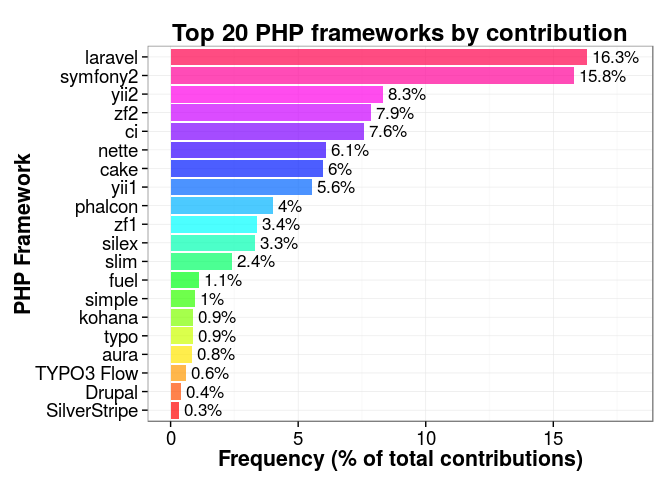

```r
contrib.summ <- contrib.long %>%
  group_by(framework) %>%
  summarise(freq=n(), pfreq=100*n()/nrow(contrib.long)) %>%
  arrange(desc(freq))
contrib.summ$framework <- factor(contrib.summ$framework,
                                levels=rev(contrib.summ$framework),
                                ordered=TRUE)
top20 <- contrib.summ[1:20,]

ggplot(top20, aes(x=framework, y=pfreq)) +
  geom_bar(stat="identity", fill=rainbow(20), alpha=0.7) +
  geom_text(label=paste0(" ",round(top20$pfreq,1), "%"), hjust=0, size=4.5) +
  xlab("PHP Framework") +
  ylab("Frequency (% of total contributions)") +
  ylim(c(0,18)) +
  ggtitle("Top 20 PHP frameworks by contribution") +
  coord_flip() +
  theme_bw() +
  theme(axis.text=element_text(size=14),
        axis.title=element_text(size=16, face="bold"),
        plot.title=element_text(size=18, face="bold"))
```

## Comparisons with the votes for popular frameworks

Let’s now look at the correspondence between frameworks used for work and personal projects, and whether the respondent contributes to at least one framework.

```r
personal <- survey[,c(1,5:11,21,30)]
survey$samefw <- survey$fw.work.choice == survey$fw.personal.choice
survey$contributes <- rowSums(contrib[, -1], na.rm=TRUE) > 0
(xt1 <- xtabs( ~ samefw + contributes, survey))
```

```
##        contributes
## samefw  FALSE TRUE
##   FALSE  2055  350
##   TRUE   4272 1058
```

Out of every ~7 people who use different frameworks for work and personal projects, 1 contributes to at least one of those frameworks. And, out of ~5 people who use the same framework at work and personal projects, 1 contributes to at least one framework.

```r
xt2 <- round(100*xt1 / nrow(survey), 1)
```

If we look at this in overall percentages of respondents, we find that:

- 26.6% use different frameworks for work and personal projects, and do not contribute to any framework
- 4.5% use different frameworks but contribute to at least one framework
- 55.2% use the same framework for work and personal projects, but do not contribute to any framework
- 13.7% use the same framework and contribute to at least to one of them

Will there be a difference between contributions for the most popular framework (according to Sitepoint’s 2015 survey): Laravel? How about for the second most popular: Symfony2?

Again, we use dplyr to summarize this data. First for the use at work, filtering for the cases where the total number of entries of at least 20 for the framework, and for entries with an empty name:

```r
contrib_fw_work <- survey %>%
  select(id, fw.work.choice, contributes) %>%
  group_by(fw.work.choice) %>%
  summarise(ncontrib=sum(contributes), ntotal=n()) %>%
  filter(ntotal >= 20 & fw.work.choice !="" ) %>%
  mutate(pcontrib=ncontrib/ntotal) %>%
  arrange(desc(pcontrib))
contrib_fw_work %>% filter(fw.work.choice %in% c("Laravel", "Symfony2"))
```

```
## Source: local data frame [2 x 4]
##
##   fw.work.choice ncontrib ntotal  pcontrib
## 1       Symfony2      245   1067 0.2296157
## 2        Laravel      273   1658 0.1646562
```

And next for the personal use:

```r
contrib_fw_personal <- survey %>%
  select(id, fw.personal.choice, contributes) %>%
  group_by(fw.personal.choice) %>%
  summarise(ncontrib=sum(contributes), ntotal=n()) %>%
  filter(ntotal >= 20 & fw.personal.choice !="" ) %>%
  mutate(pcontrib=ncontrib/ntotal) %>%
  arrange(desc(pcontrib))
contrib_fw_personal %>% filter(fw.personal.choice %in% c("Laravel", "Symfony2"))
```

```
## Source: local data frame [2 x 4]
##
##   fw.personal.choice ncontrib ntotal  pcontrib
## 1           Symfony2      241   1005 0.2398010
## 2            Laravel      314   2110 0.1488152
```

So Laravel (the most popular framework) has a community engamement (contribution) of about 15-16%, and Symfony2 something between 23-24%.

If we look at the top 3 frameworks as measured by contributions, the situation is quite different than the popularity statistics:

```r
kable(contrib_fw_work[1:3,], digits = 2,
      caption="Ranking of frameworks used at work by contribution")
```

Ranking of frameworks used at work by contribution

| fw.work.choice | ncontrib | ntotal | pcontrib |
| --- | --- | --- | --- |
| Typo 3 | 20 | 35 | 0.57 |
| CakePHP | 80 | 254 | 0.31 |
| Zend Framework 2 | 109 | 390 | 0.28 |

```r
kable(contrib_fw_personal[1:3,], digits = 2,
      caption="Ranking of frameworks used for personal projects by contribution")
```

Ranking of frameworks used for personal projects by contribution

| fw.personal.choice | ncontrib | ntotal | pcontrib |
| --- | --- | --- | --- |
| Typo 3 | 12 | 20 | 0.60 |
| CakePHP | 73 | 229 | 0.32 |
| Zend Framework 2 | 107 | 346 | 0.31 |

It is interesting that these are frameworks that are quite mature and have been around for quite some time.

## Modeling contribution

The following is not strict modeling, at best it is a preliminary exploration on trying to figure out if it is possible to understand contributions in terms of the variables acquired.

First, we need to calculate the base accuracy, i.e. assigning to all rows the most frequent value for contribution (`FALSE`).

```r
(base_acc <- sum(survey$contributes==FALSE) / nrow(survey))
```

```
## [1] 0.8179703
```

Then, we try a logistic regression (why not?), and let’s not worry about possible colinearity and other hairy issues.

```r
survey$age.group <- factor(survey$age.group)
survey$education <- factor(survey$education)
logmodel <- glm(contributes ~ samefw + age.group + years.php +
                years.programming + education + numframeworks,
                data=survey, family="binomial")
summary(logmodel)
```

```
##
## Call:
## glm(formula = contributes ~ samefw + age.group + years.php +
##     years.programming + education + numframeworks, family = "binomial",
##     data = survey)
##
## Deviance Residuals:
##     Min       1Q   Median       3Q      Max
## -2.3538  -0.6675  -0.5746  -0.4538   2.6024
##
## Coefficients:
##                     Estimate Std. Error z value Pr(>|z|)
## (Intercept)       -2.4184238  0.2683388  -9.013  < 2e-16 ***
## samefwTRUE         0.3937101  0.0686493   5.735 9.75e-09 ***
## age.group2         0.2776321  0.2564490   1.083 0.278985
## age.group3        -0.1709346  0.2594904  -0.659 0.510068
## age.group4        -0.4791895  0.2786983  -1.719 0.085544 .
## age.group5        -1.2118313  0.3650170  -3.320 0.000900 ***
## years.php          0.0665785  0.0121997   5.457 4.83e-08 ***
## years.programming  0.0008912  0.0092778   0.096 0.923473
## education2        -0.0907414  0.1302166  -0.697 0.485897
## education3        -0.4092336  0.1394284  -2.935 0.003335 **
## education4        -0.2101331  0.1028052  -2.044 0.040954 *
## education5        -0.0983835  0.0884050  -1.113 0.265763
## education6         0.1336008  0.0992409   1.346 0.178229
## education7         0.8844739  0.2572563   3.438 0.000586 ***
## numframeworks      0.0982868  0.0155403   6.325 2.54e-10 ***
## ---
## Signif. codes:  0 '***' 0.001 '**' 0.01 '*' 0.05 '.' 0.1 ' ' 1
##
## (Dispersion parameter for binomial family taken to be 1)
##
##     Null deviance: 7339.9  on 7734  degrees of freedom
## Residual deviance: 7099.5  on 7720  degrees of freedom
## AIC: 7129.5
##
## Number of Fisher Scoring iterations: 4
```

```r
logpred <- predict(logmodel, type="response")
(logct <- table(logpred >= 0.5, survey$contributes))
```

```
##
##         FALSE TRUE
##   FALSE  6317 1394
##   TRUE     10   14
```

```r
(log_acc <- (logct[1,1] + logct[2,2]) / nrow(survey))
```

```
## [1] 0.8184874
```

The logistic model seem to indicate that the total number of years of programming experience is not as significative, as, for example, the number of year programming in PHP, at least to predict contributions to PHP frameworks.

As we can see there is a slight improvement in the accuracy using this naive model, going from 0.8179703 (the base value) to 0.8184874, a difference of just $5.1712993\times 10^{-4}$

We can now plot and calculate the AUC that we can expect with this model.

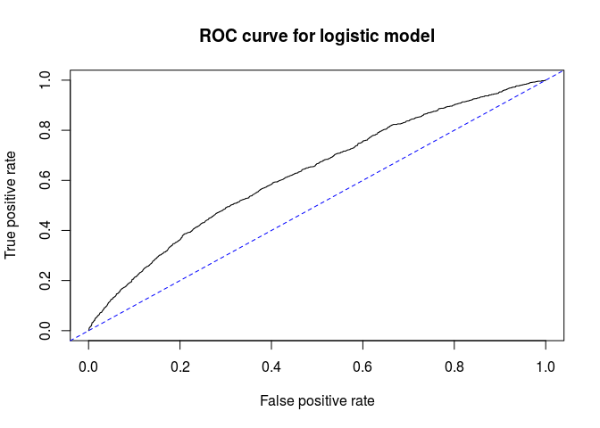

```r
rpred1 <- prediction(logpred, survey$contributes)
perf1 <- performance(rpred1, measure="tpr", x.measure="fpr")
plot(perf1, main="ROC curve for logistic model")
abline(a=0, b=1, lty="dashed", col="blue")
```

```r
(auc1 <- as.numeric(performance(rpred1, "auc")@y.values))
```

```
## [1] 0.6288363
```

Better than the baseline of 0.5, but not that great. Also, this model gives us still a great number of false negatives: people predicted not to contribute, but that do otherwise.

Finally we will try to use a classification tree, and see if can get a better model.

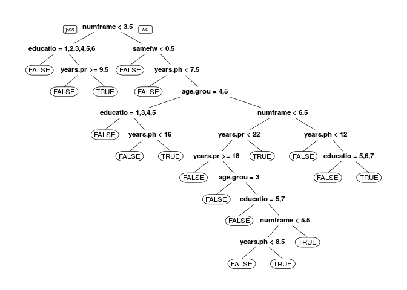

```r
treemodel <- rpart(contributes ~ samefw + age.group + years.php +
               years.programming + education + numframeworks,
               data=survey,
               method = "class", cp=0.001)
prp(treemodel)
```

```r
treepred <- predict(treemodel, type="class")
(treect <- table(treepred, survey$contributes))
```

```
##
## treepred FALSE TRUE
##    FALSE  6303 1352
##    TRUE     24   56
```

```r
(tree_acc <- (treect[1,1] + treect[2,2]) / nrow(survey))
```

```
## [1] 0.8221073
```

Bottomline: I am not convinced that we can model contribution using the variables collected in this survey. Of course, that was not the goal of the survey, so it there is no surprise there.

[^1]: http://www.sitepoint.com/best-php-framework-2015-sitepoint-survey-results/
[^2]: https://github.com/sitepoint-editors/php-fw-survey-2015